# Part I - The Loan Original Amount For Borrowers And Its Interactions With Some Other Loan Features

### Exploration_U5

#### Question:

> How is ProsperScore distributed for the loan applicants?

#### Visualization:

```python
print(df_clean.ProsperScore.nunique())
print(df_clean.ProsperScore.unique())
df_clean.ProsperScore.value_counts()
```

```
10
[nan  7.  9.  4. 10.  2.  8.  5.  3.  6.  1.]
```

```
4.0     12595
6.0     12278
8.0     12053
7.0     10597
5.0      9813
3.0      7642
9.0      6911
2.0      5766
10.0     4750
1.0       992
Name: ProsperScore, dtype: int64
```

```python
df_clean.ProsperScore.value_counts(normalize = True).round(4)
```

```
4.0     0.1510
6.0     0.1472
8.0     0.1445
7.0     0.1271
5.0     0.1177
3.0     0.0916
9.0     0.0829
2.0     0.0691
10.0    0.0570
1.0     0.0119
Name: ProsperScore, dtype: float64
```

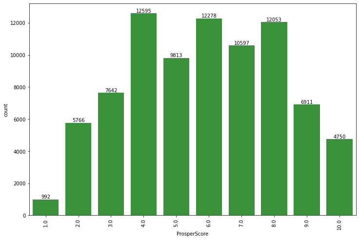

```python
base_color = sb.color_palette()[2]

anycountplot(df_clean, 'ProsperScore', None)
```

#### Observation:

> Applicable to loans originated after July 2009, 992 of the loans were high risk after getting a Prosper Score of 1.0 while 4750 loans were the lowest risk or best loans for a Prosper Score of 10.0. However, between this range, majority of the loans got varying Prosper Score. Prosper score 4.0 recorded the most of customers who got loans from Prosper.

### Exploration_U6

#### Question:

> How is the ownership of a home or otherwise by borrowers distributed?

#### Visualization:

```python
df_clean_homeowner = df_clean.IsBorrowerHomeowner.value_counts()
df_clean.IsBorrowerHomeowner.value_counts(normalize=True).round(4)
```

```
True     0.5024
False    0.4976
Name: IsBorrowerHomeowner, dtype: float64
```

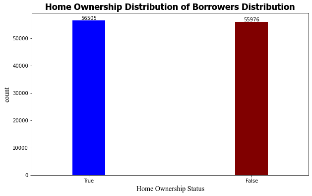

```python
ax = df_clean_homeowner.plot(kind='bar', color=['b','#800000'], figsize=(10,6), width=0.2);

# Labeling the axes
plt.xlabel('Home Ownership Status', fontdict={'family':'Times New Roman', 'fontsize':14, 'color':'k'});
plt.ylabel('count', fontdict={'family': 'Times New Roman', 'fontsize':14,  'color':'k'});

parameter={'axes.titlesize':18, 'axes.titleweight':'bold',}
plt.rcParams.update(parameter)
plt.title('Home Ownership Distribution of Borrowers Distribution', family='Tahoma', fontstyle='normal', color='k')

plt.xticks(rotation = 0)

# Annotating the bars of the plot
ax.bar_label(ax.containers[0])

# Dsiplay the plot
plt.show()
```

#### Observation:

> More borrowers were homeowners as oppose those borrowers who did not own a home. 56505, constituting 50.24% of borrowers were home owners, while 55976 of the borrowers constituting 49.76% did not have a home.

### Exploration_U7

#### Question:

> What is the distribution of the EmploymentStatus?

#### Visualization:

```python
# Creating an ordered sequence for the nominal EmploymentStatus feature

employment_status =df_clean.EmploymentStatus.value_counts().index
print(df_clean.EmploymentStatus.value_counts())
employment_status
```

```
Employed         65957
Full-time        26341
Self-employed     6091
Not available     5347
Other             3772
Part-time         1088
Not employed       835
Retired            795
Name: EmploymentStatus, dtype: int64
```

```
Index(['Employed', 'Full-time', 'Self-employed', 'Not available', 'Other',
       'Part-time', 'Not employed', 'Retired'],
      dtype='object')
```

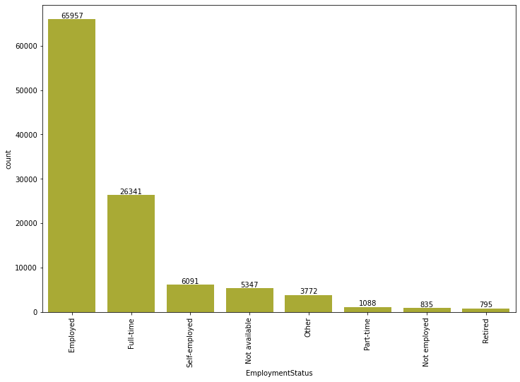

```python
base_color = sb.color_palette()[8]

anycountplot(df_clean, 'EmploymentStatus', employment_status)
```

#### Observation:

> While 65957 borrowers were labelled as Employed, and 26341 were had employment status Full-time, 6091 were Self-employed. Beyond these the remainder of the borrowers were either not available, were part-time employees, not employed, retired or classified under other types of employment. 795 of the over 110000 borrowers were retired.

### Exploration_U8

#### Question:

> What is the distribution of the BorrowerState?

**User-defined function for creating horizontal plots of nominal data using seaborn**

```python
def hcountplot(df, yVar, ordertype):

    figure = plt.figure(figsize = [16, 16])

    ax = sb.countplot(data = df, y= yVar, order = ordertype, color = base_color);

    ax.bar_label(ax.containers[0])
    plt.show()
```

#### Visualization:

```python
borrower_state = df_clean.BorrowerState.value_counts().index
```

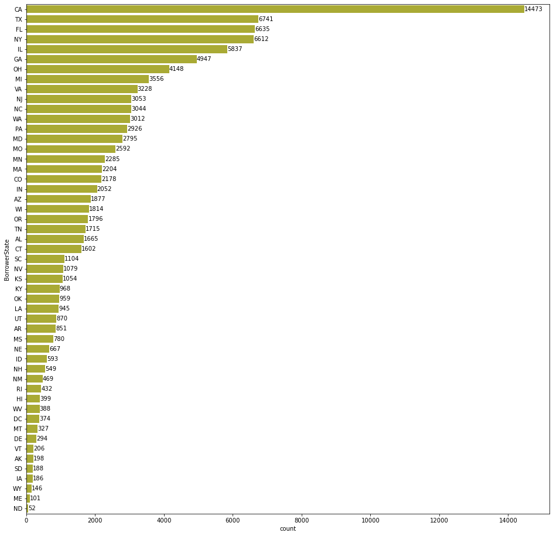

```python
base_color = sb.color_palette()[8]

hcountplot(df_clean, 'BorrowerState', borrower_state)
```

#### Observation:

> Lending was not evenly distributed to borrowers from all the states. Borrowers from the state of CA were the most to apply for loans and the most likely to have their loan applications granted as compared to those from ND.